# MIDI-MT - Управление аудио сеансами запущенных приложений

MIDI-MT Документация на Русском языке

## Управление **аудио сеансами** запущенных приложений

Дополнительно, есть возможность управлять **аудио сеансами** запущенных приложений. Управление может происходить как с MIDI клавиатуры, так и со встроенной панели управления звуком.

[figure not shown]

Панель управления аудио сессиями имеет несколько тем. Вы можете подобрать оформление панели согласно своему вкусу и теме оформления вашего рабочего стола. Также, есть настраиваемая тема, в ней вы сможете изменять все цвета по своему усмотрению.

### Доступны следующие темы оформления панели:

- `Светлая`,
- `Темная`,
- `Метро`,
- `Ретро`,
- `Современная`,
- `Настраиваемая`

Размещение панели на экране имеет четыре фиксированные начальные позиции:

- `вертикально - справа`,
- `вертикально - слева`,
- `горизонтально вверху`,
- `горизонтально внизу`

Вы можете перемещать панель в плоскости её расположения по собственному усмотрению. Другими словами, панели в горизонтальном положении, можно перемещать по вертикали, а панели в вертикальном положении, по горизонтали. На панели можно регулировать громкость и отключение звука для каждой сессии. Регулировка возможна как с MIDI клавиатуры так и мышкой, с помощью встроенной аудио панели.

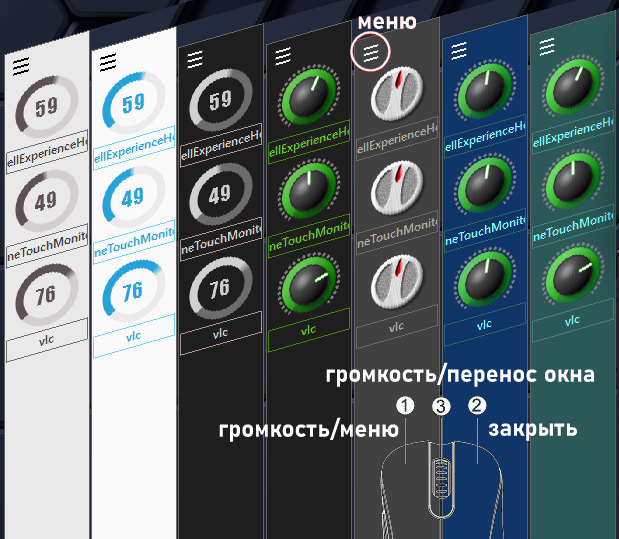

Для управления аудио сессиями с MIDI клавиатуры, вызывать панель нет необходимости. Панель необходима только для регулировки звука с помощью мышки, или для визуализации состояния текущих аудио сессий.

### Настройка

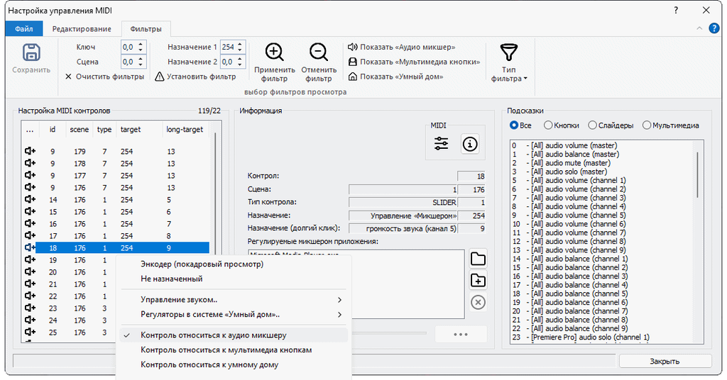

После этого, вы должны добавить в список приложений полный путь к управляемой программе. Редактор в процессе обработки сам превратит его в нужный формат, это значение будет идентификатором приложения. Добавить приложение можно через диалог выбора файлов, указав на диске нужный исполняемый файл, или через кнопку `загруженные приложения`. В последнем случае, добавятся все запущенные приложения, имеющие открытую аудио сессию. Лишние можно удалить.

Количество управляемых приложений на один `контрол` неограниченно. Но надо помнить, что если загружены будут несколько приложений, указанных одному `контролу`, то регулировка звука будет происходить только у последнего.

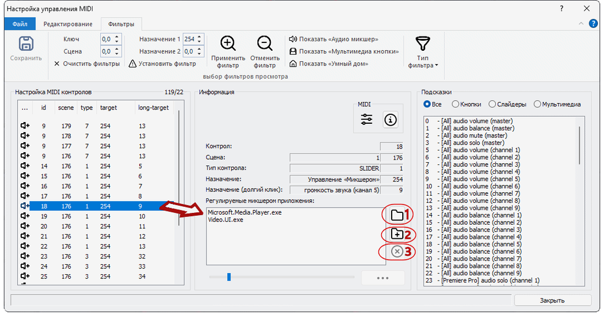

Особенно актуально, использование встроенного микшера для управления звуком в Windows 11, где привычные средства регулировки звука удалили, а доступ к имеющимся, связан с долгим путешествием по меню настроек.